# R Notebook

# Bar plots

Aurthor: Jiesheng Zheng

Bar plots are most common way to show the data distribution. In biology, we often use bar plots to show the gene expression level, as well as Go enrichment analysis. (if you want to know what is [gene expression](https://www.nature.com/scitable/topicpage/gene-expression-14121669/) or [Go enrichment analysis](http://geneontology.org/docs/go-enrichment-analysis/), please click.) In this sectionk, we not only introduce basic bar plots ploting but also show how to draw stacked bar plots.

Basic bar plots is very easy to draw. Here I give an example. a dataset giving 4 gene expression in 5 samples.

```r
# Create the variable
data_ori = "Grp_1;Grp_2;Grp_3;Grp_4;Grp_5
a;2.6;2.9;2.1;2.0;2.2
b;20.8;9.8;7.0;3.7;19.2
c;10.0;11.0;9.2;12.4;9.6
d;9;3.3;10.3;11.1;10"
# Load into the table
data = read.table(text=data_ori, header=T, row.names=1, sep=";", quote="")
data
```

|  | Grp_1 | Grp_2 | Grp_3 | Grp_4 | Grp_5 |
| --- | --- | --- | --- | --- | --- |
| a | 2.6 | 2.9 | 2.1 | 2.0 | 2.2 |
| b | 20.8 | 9.8 | 7.0 | 3.7 | 19.2 |
| c | 10.0 | 11.0 | 9.2 | 12.4 | 9.6 |
| d | 9.0 | 3.3 | 10.3 | 11.1 | 10.0 |

We should first reshape the data. We keep the gene name. Installing packages is required. Here we will use **ggplot2** , **reshape2** , and **dplyr**.

```r
# Load packages
install.packages("ggplot2")
```

```
Error in install.packages : Updating loaded packages
```

```r
install.packages("reshape2")
install.packages("dplyr")
```

```
Error in install.packages : Updating loaded packages
```

```r
library(ggplot2)
library(reshape2)
library(dplyr)
```

We add rownames and column names and reshape the dataset.

```r
# Process the dataset
data_rownames = rownames(data)
data_colnames = colnames(data)
data$gene = data_rownames
data_m = melt(data, id.vars=c("gene"))
data_m
```

| gene | variable | value |
| --- | --- | --- |
| a | Grp_1 | 2.6 |
| b | Grp_1 | 20.8 |
| c | Grp_1 | 10.0 |
| d | Grp_1 | 9.0 |
| a | Grp_2 | 2.9 |
| b | Grp_2 | 9.8 |
| c | Grp_2 | 11.0 |
| d | Grp_2 | 3.3 |
| a | Grp_3 | 2.1 |
| b | Grp_3 | 7.0 |

[output cut: 10 more lines]

Now we can draw bar pltos, first we can observe genes expression in different groups.

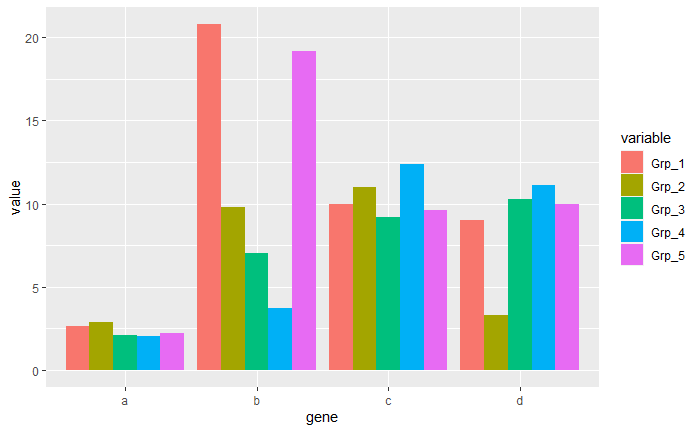

```r
# Draw bar plots
p = ggplot(data_m, aes(x=gene, y=value))
p + geom_bar(stat="identity", position="dodge", aes(fill=variable))
```

Opps! Maybe lots of bars in one plot. In oder to have a better view, we can use **group_by** command to group the data by **gene**, and use **summarise* to give a summary. We can use show plots by mean+-SD.(calculate the mean and standard and deviation)

```r
# Get mean and SD
data_m_sd_mean = data_m %>% group_by(gene) %>% dplyr::summarise(sd=sd(value), value=mean(value))

data_m_sd_mean = as.data.frame(data_m_sd_mean)

data_m_sd_mean
```

| gene | sd | value |
| --- | --- | --- |
| a | 0.3781534 | 2.36 |
| b | 7.5491721 | 12.10 |
| c | 1.2837445 | 10.44 |
| d | 3.1325708 | 8.74 |

We can also add error bars.

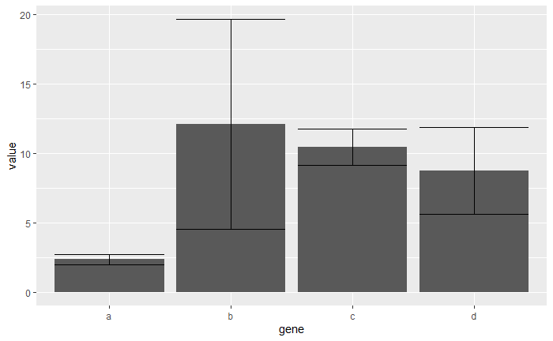

```r
# Draw the plot.
p = ggplot(data_m_sd_mean, aes(x=gene, y=value)) +
    geom_bar(stat="identity") +
    geom_errorbar(aes(ymin=value-sd, ymax=value+sd))
p
```

Adding some colours might be perfect.

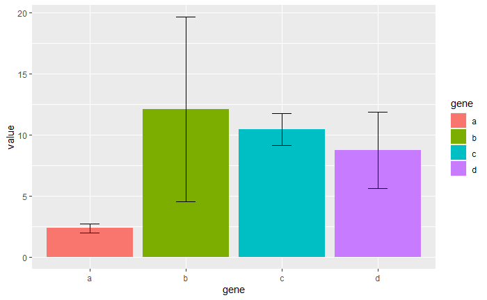

```r
# Beautify bar plots
p = ggplot(data_m_sd_mean, aes(x=gene, y=value)) +
    geom_bar(stat="identity", aes(fill=gene)) +
    geom_errorbar(aes(ymin=value-sd, ymax=value+sd), width=0.2, position=position_dodge(width=0.75))
p
```

Now, if you want to show the original value for each gene expression, the only thing you do is to correct **position = stack**.

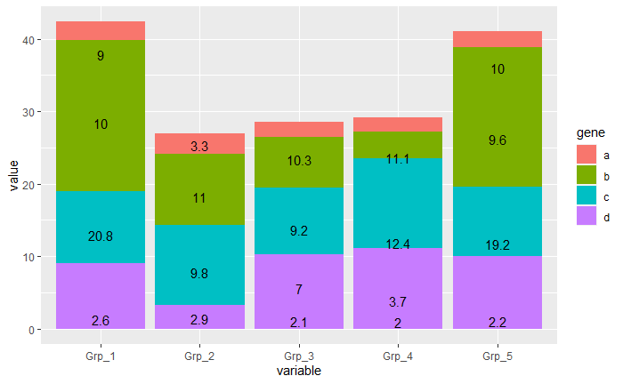

```r
# Draw stack bar plots
p = ggplot(data_m, aes(x=variable, y=value)) +
    geom_bar(stat="identity", position="stack", aes(fill=gene)) +
    geom_text(aes(label=value), position=position_stack(vjust=0.5))
p
```

Opps, the texts are played in wrong places! Give the group information, and it will be corrected.

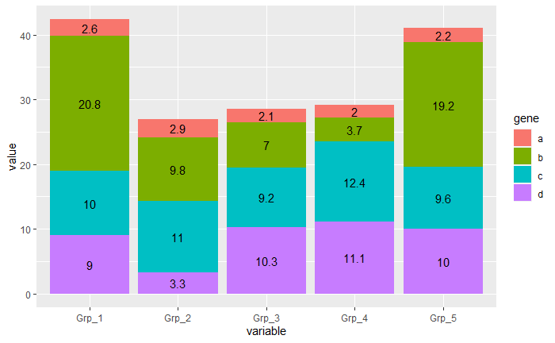

```r
# Add group information
p = ggplot(data_m, aes(x=variable, y=value, group=gene)) +
    geom_bar(stat="identity", position="stack", aes(fill=gene)) +
    geom_text(aes(label=value), position=position_stack(vjust=0.5))
p
```

Now we want to compare relative expression in each gene. We can use **position = fill**. Stack shows the actual original number whiile Fill is for the proportion. We change y axis into the percentage.

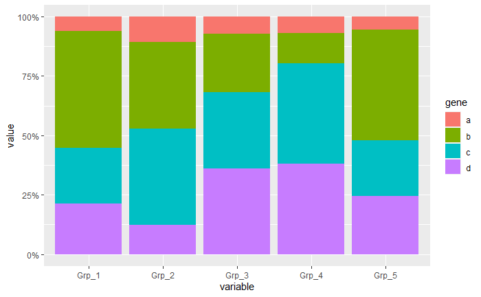

```r
p = ggplot(data_m, aes(x=variable, y=value)) +
    geom_bar(stat="identity", position="fill", aes(fill=gene)) +
    scale_y_continuous(labels = scales::percent)
p
```

We also want to show percentage in each part of each bar. We can first calculate percentage by using **group_by** and **mutant**.

```r
# First add together in each group and then calculate the proportion
data_m = data_m %>% group_by(variable) %>% mutate(count=sum(value)) %>% mutate(freq=round(100*value/count,2))
```

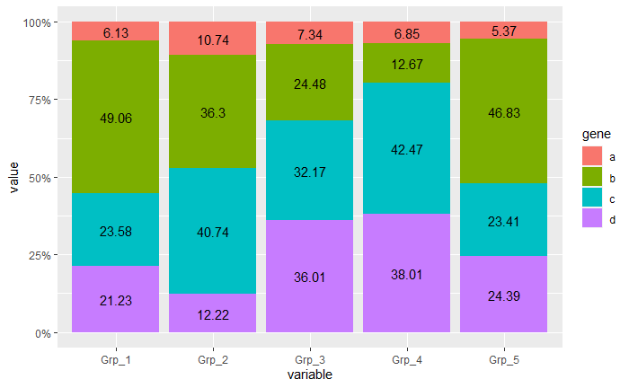

```r
# Draw bar plots
p = ggplot(data_m, aes(x=variable, y=value, group=gene)) +
    geom_bar(stat="identity", position="fill", aes(fill=gene)) +
    scale_y_continuous(labels = scales::percent) +
    geom_text(aes(label=freq), position=position_fill(vjust=0.5))
p
```